# 5 November Meeting Figures

## How much time do pre-breeders spend attending colonies?

One natural question about pre-breeder colony attendance is how much time individuals spend attending colonies. What they do while attending colonies is restricted by how much time they have to do it, and time they spend at colonies is time they can’t spend foraging, migrating, etc. Instananeous or point-count observations of young individuals at colonies cannot answer this question, nor can data from GPS tags with long intervals between fixes.

My first question is how much time each of our tagged individuals spent attending any colony. We can further break that time down by colony, and ask the extent to which individuals spent more time at the colony where they were tagged.

In my season report for Jake and Sabina, I grouped detections for each individual into three-minute bins, filtered out bins where detections were received on only one antenna, then defined the island on which the bird was present in each bin as the island which had the greater number of antennas hit. Then, instead of turning the number of bins into a duration of time, I simply looked at the proportion of bins assigned to each island. I am unhappy with this approach for a few reasons:

1. Birds often “hang out” on one antenna in cases where I think it’s very likely that they *are* on an island. For example:

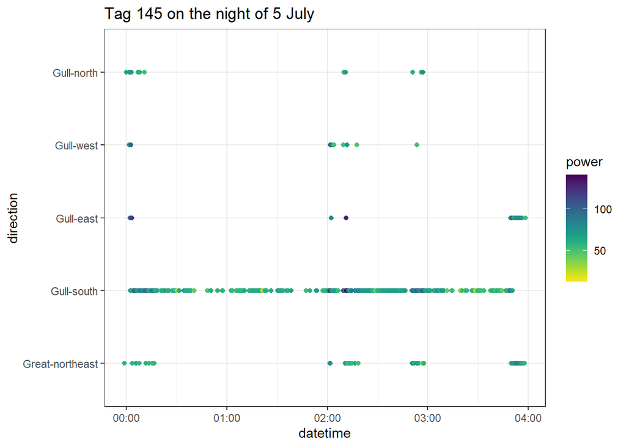

In this case, bird #145 spends a lot of time only being heard by the south-facing antenna on Gull, and not by any other antenna. I think it’s likely that the bird was, during those periods, close enough to the island to “count”, but may have been low to the ground or otherwise in a low-detection area. In my old method, those periods where the bird was only on the south-facing antenna would have been dropped from the bird’s total attendance time. This doesn’t really make sense, because even if the bird is on the water instead of on the island, it is still spending that time in the area, and not foraging or doing anything else.

2. Birds often go “missing” for several minutes while attending the colonies, when they are obviously still in the area, because they come right back. For example:
3. Assigning birds to island by the receiver which had the most antennas represented might overlook cases where a detection on one antenna is very strong, but the bird is still in (weakly) range of multiple antennas from another island. I don’t think this has ever happened, but it is possible.

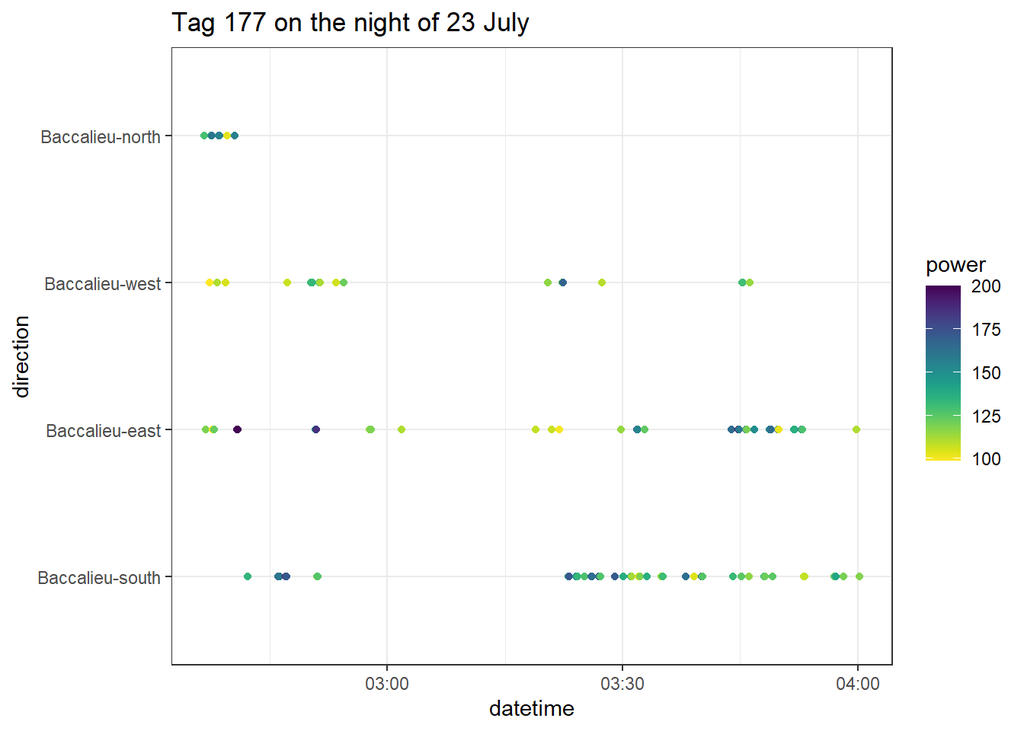

In this case, bird #177 is “missing” between ~03:00 and 03:15, so in my prior method those bins would have been excluded from calculating its total attendance time. Again, the immediate reappearance of the bird makes me think that those “missing” minutes should still be counted, because the bird is clearly in the area during that time. Perhaps individuals briefly go out to sea, or go into burrows for a few minutes, or just fly into gullies or behind rocks and so disappear from the receiver. But again, this is clearly time spent prospecting rather than foraging, etc.

My new strategy is to group detections into “segments,” where the segment number changes when 1) the island that the bird is on changes or 2) the night-of date changes. So a bird that visited Gull over two separate nights would have two segments, and a bird that visited Gull, then Great, then Gull again would have three segments. I have grouped detections into two-minute bins, then assigned each bin to an island based on which station received the strongest mean detections within that bin (this is a mean of a mean; the mean power for each individual antenna is taken for each bin, then those means are averaged for each island). The segment length is then calculated by subtracting the earliest time in each segment from the latest time.

In the case where a segment is represented by only one bin, I set the segment length to 60 seconds (one scan cycle). A more conservative approach for one-bin segments might be to assign their length based on the number of detections in the bin; for example, if a bird was detected 5 times in a two-minute segment, the minimum time it could have been present would be 5 * 7.5 = 37.5 seconds, based on the burst interval between detections.

This code chunk loops through each tag ID and groups detections into segments based on changes to nightdate or island. I have only included birds that came back to visit a colony at least once after being tagged:

```r
visit_segments_loop <- data.frame()

visitors <- prospecting_detections %>%
  filter(nightdate != capture_nightdate) %>%
  group_by(tag_id) %>%
  count() %>%
  dplyr::select(tag_id)

visitors <- as.list(visitors$tag_id)

for (i in visitors) {

groups = list(1)
counter = 1

df <- prospecting_detections %>%
  filter(tag_id == i) %>%
  #filter(nightdate != capture_nightdate) %>%
  mutate(bin = binner(datetime, "2 mins")) %>%
  group_by(tag_id, bin, island, direction, capture_nightdate) %>%
  summarize(mean_power = mean(power), n_detections = n()) %>%
  group_by(tag_id, bin, island, capture_nightdate) %>%
  summarize(mean_power_across = mean(mean_power), n_detections = sum(n_detections)) %>%
  group_by(tag_id, bin) %>%
  slice(which.max(mean_power_across)) %>%
  mutate(nightdate = nightdater(bin))

  for (n in 2:length(df$tag_id)) {

    if (df$island[n] == df$island[n-1] & as.character(df$nightdate[n]) == as.character(df$nightdate[n-1])) {
      groups <- append(groups,counter)
     # print("same")
     } else {
      counter = counter + 1
      groups <- append(groups,counter)

      #print("dif")
    }

  }

groups <- as.data.frame(groups)

groups <- groups %>%
  pivot_longer(everything())

df <- cbind(df, groups$value) %>%
  dplyr::rename(segment = `...8`)

visit_segments_loop <- rbind(visit_segments_loop, df)
}
```

By adding together the segment lengths for each bird, we can more accurately quantify the amount of time that each bird spent attending any colony:

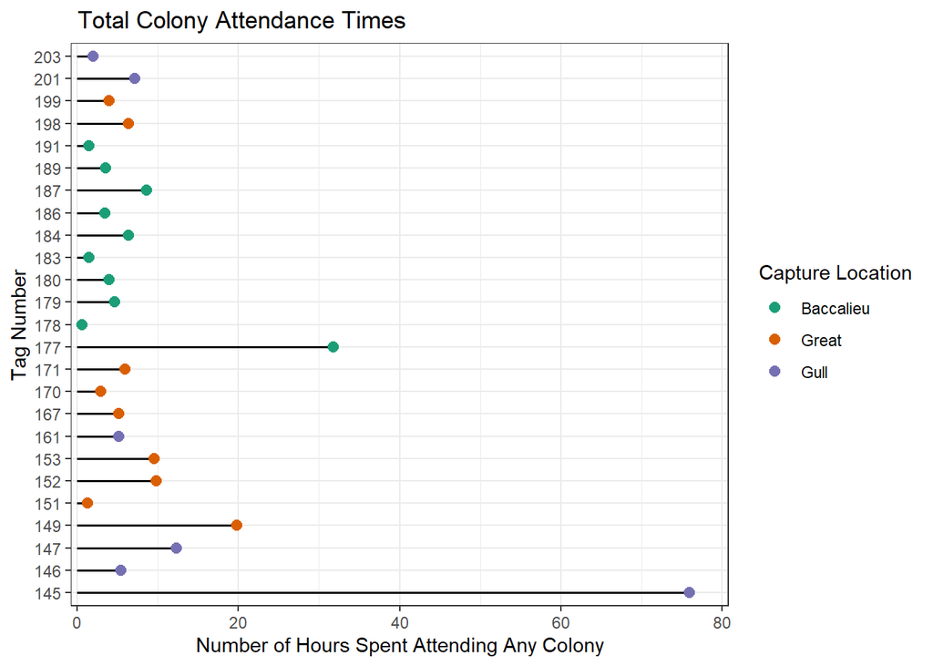

We can also break attendance time down by colony, and look at how attendance time varied based on island of capture. For each bird:

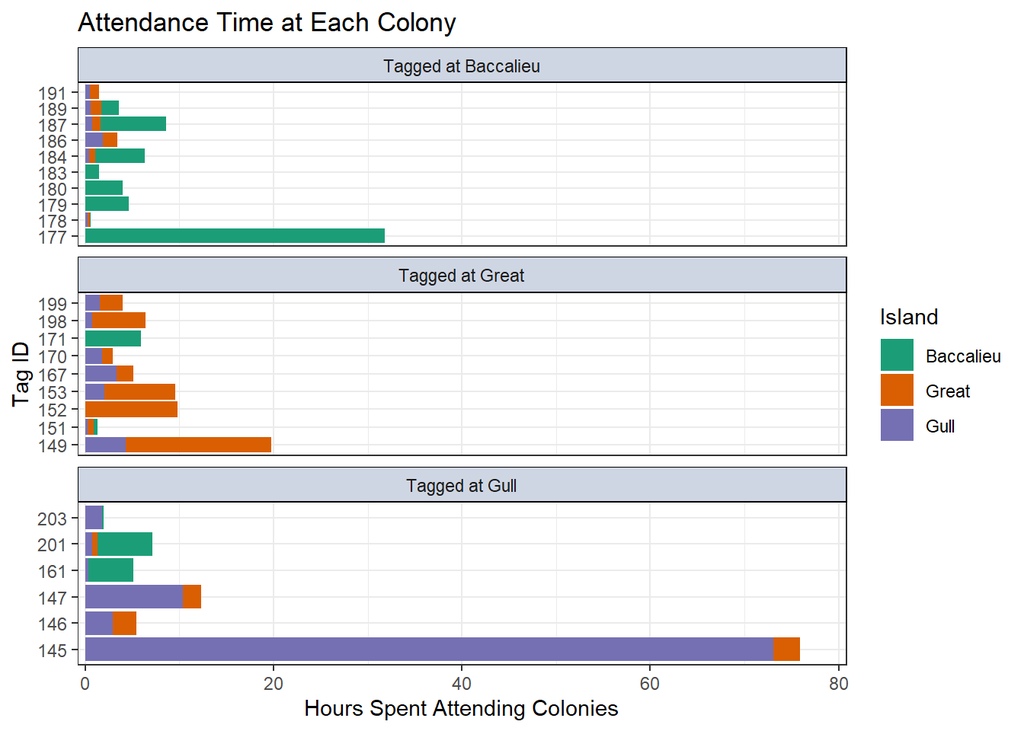

We can also look at the total amount of time spent at each colony by all birds, grouped together by where they were tagged:

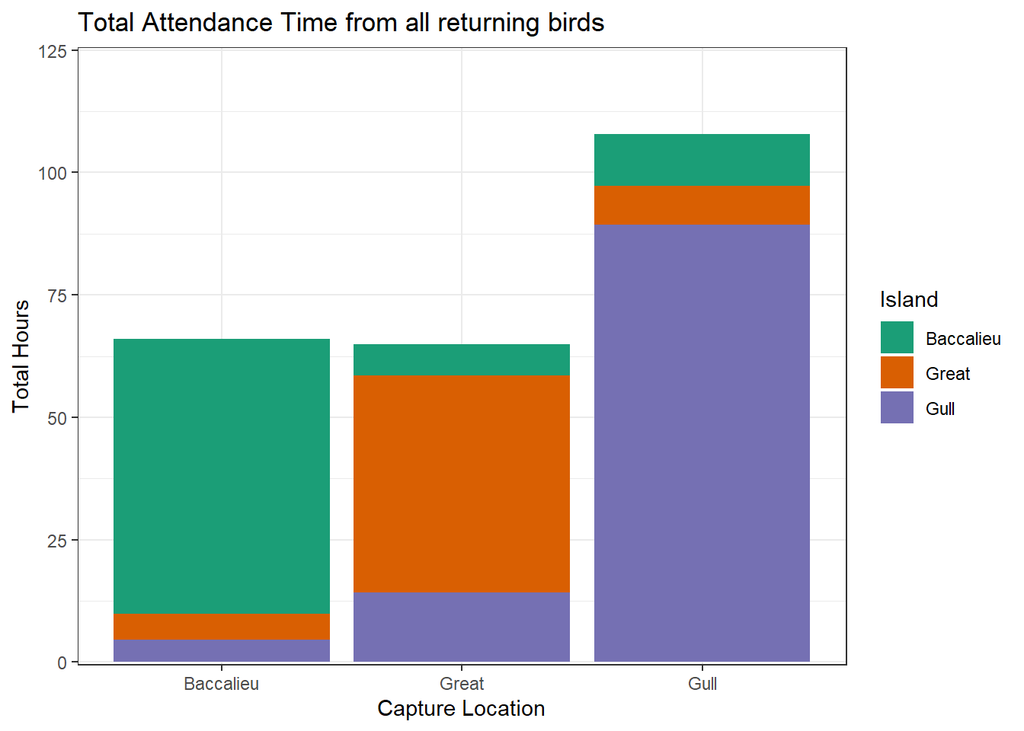

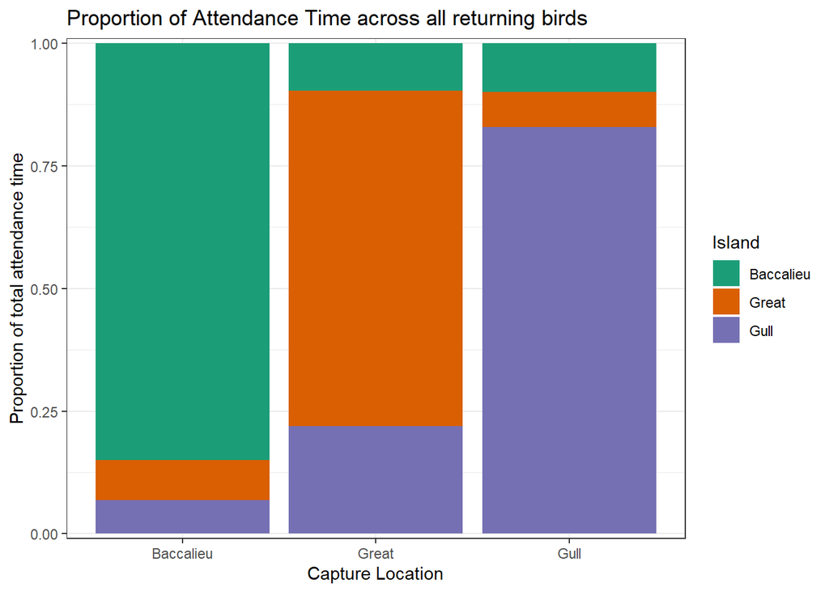

And at the distribution of attendance time birds spent at each island, grouped by where they were tagged:

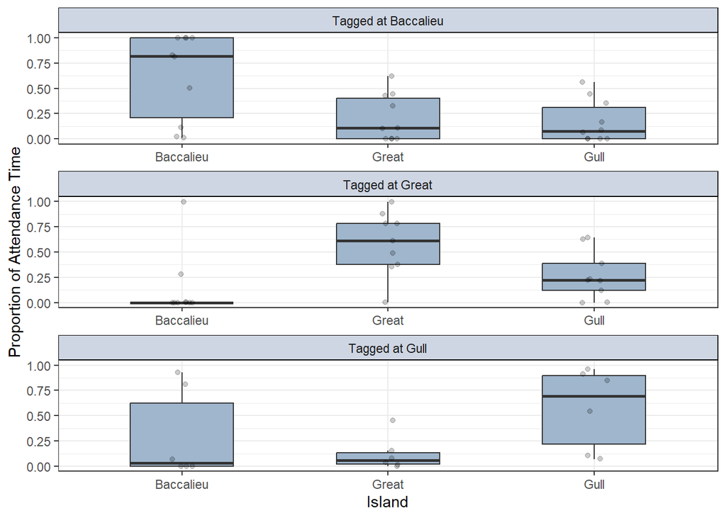

These figures all capture essentially the same pattern: Birds are quite variable in the amount of time they spent attending colonies (and this sample only includes birds that visited at least once after being tagged), and show a general preference for the colony where they were tagged, though some individuals are exceptions. I am trying to decide what the best way to actually test for colony preference might be. Another next step would be to divide the total amount of time each bird spent at the colonies by the length of individual colony visits, to get a sense of how much they “focus” their attention on one colony or another, and to get a sense of the distribution of individual visit lengths. I could also incorporate light data here, and look at the length of island visits relative to the amount of darkness available.

Another way of looking at total colony attendance time is to ask how many nights each bird spent attending colonies relative to the number of nights we could have detected them. A bird that spends every possible night at a colony is having a different experience, especially relative to foraging opportunity, than one that spends one night in seven at a colony. First, I calculated each bird’s detectable period as the period between its last detection and the night it was tagged. This is the same as how I’ve calculated tag retention. Then, I counted the number of unique nights on which the bird was present at any colony. Again, this sample only includes birds that visited the colonies at least once after being tagged.

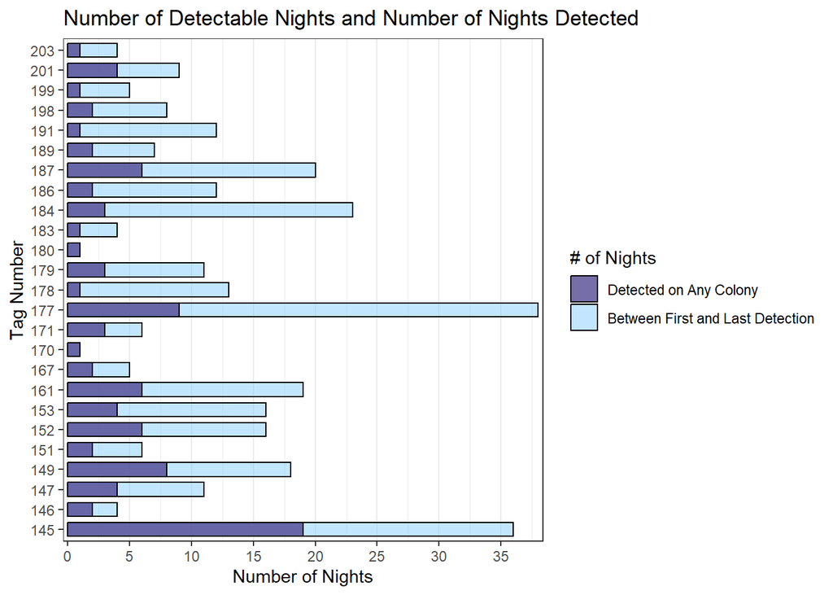

A couple of birds were detected only once, on the night after they were tagged. The distribution of visitation rates looks like this:

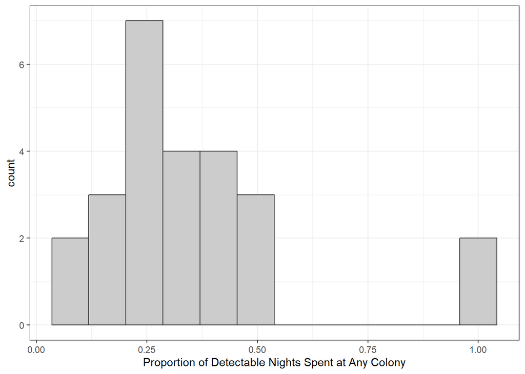

## Factors Affecting Likelihood of Returning At All

I am interested in whether we can detect any factors that might predict whether a bird was likely to return to the colonies after being tagged. I am interested in the effect of tagging date, moon age at time of tagging (another way to do this would be to look at average moon illumination in the week or two weeks after tagging), capture location, and the bird’s body mass : wing chord ratio. Eventually I will want to include sex in this model.

Here, I am setting up whether each bird returned to the colonies at all as a binary (1 for returned, 0 for never returned) and running a GLM with a binomial distribution.

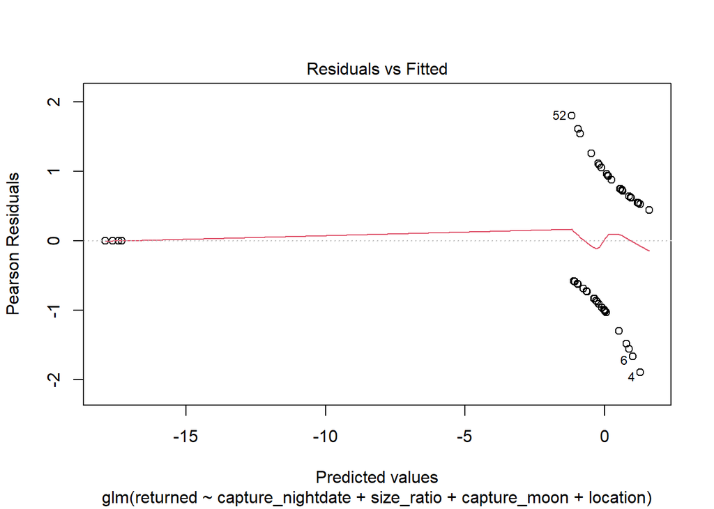

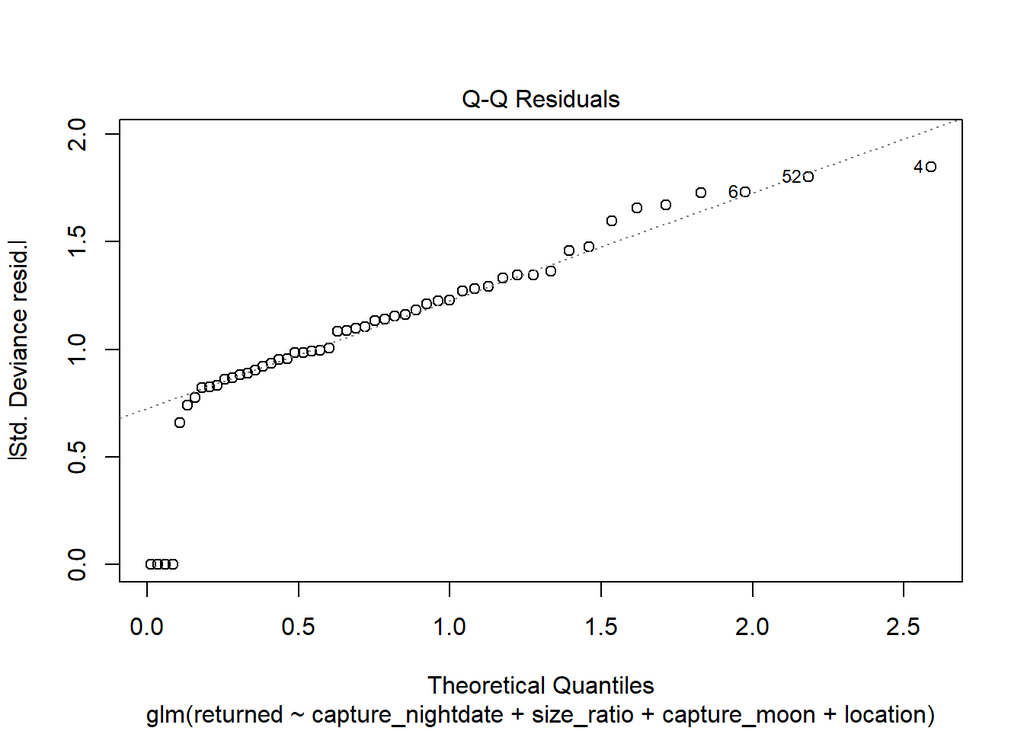

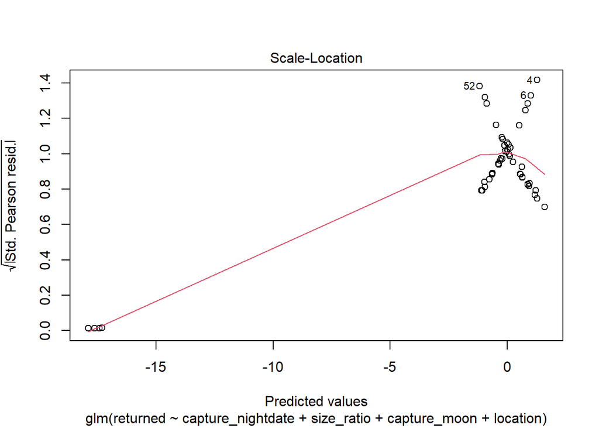

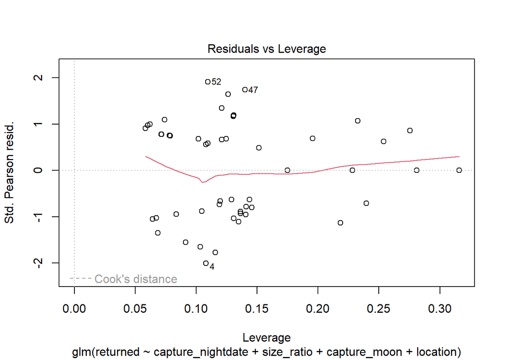

```r
bd1 <- banding_data %>%
  filter(age_class == "AHY") %>%
  mutate(returned = ifelse(tag_id %in% visitors, 1, 0)) %>%
  mutate(capture_nightdate = nightdater(end_datetime)) %>%
  mutate(capture_moon = moon.info(capture_nightdate)) %>%
  mutate(size_ratio = weight / wing_chord)

glm1 <- glm(data = bd1, returned ~ capture_nightdate + size_ratio + capture_moon + location, family = binomial(link = "logit"))

plot(glm1)
```

The leverage plot and Q-Q look pretty good. Everything else is strange because the response variable is binomial.

```
Call:
glm(formula = returned ~ capture_nightdate + size_ratio + capture_moon +
    location, family = binomial(link = "logit"), data = bd1)

Coefficients:
                      Estimate Std. Error z value Pr(>|z|)
(Intercept)          1.753e+03  8.098e+02   2.164   0.0304 *
capture_nightdate   -8.604e-02  3.978e-02  -2.163   0.0305 *
size_ratio          -2.889e+01  2.205e+01  -1.311   0.1900
capture_moon         1.741e-03  1.434e-02   0.121   0.9034
locationGreat       -3.967e-01  1.095e+00  -0.362   0.7172
locationGull        -4.257e-01  9.466e-01  -0.450   0.6529
locationMiddle Lawn -1.861e+01  1.960e+03  -0.009   0.9924
---
Signif. codes:  0 '***' 0.001 '**' 0.01 '*' 0.05 '.' 0.1 ' ' 1

(Dispersion parameter for binomial family taken to be 1)

    Null deviance: 72.010  on 51  degrees of freedom
Residual deviance: 60.716  on 45  degrees of freedom
AIC: 74.716

Number of Fisher Scoring iterations: 16
```

```
Analysis of Deviance Table

Model: binomial, link: logit

Response: returned

Terms added sequentially (first to last)

                  Df Deviance Resid. Df Resid. Dev Pr(>Chi)
NULL                                 51     72.010
capture_nightdate  1   1.0880        50     70.922  0.29693
size_ratio         1   2.4686        49     68.454  0.11614
capture_moon       1   0.3572        48     68.097  0.55004
location           3   7.3806        45     60.716  0.06071 .
---
Signif. codes:  0 '***' 0.001 '**' 0.01 '*' 0.05 '.' 0.1 ' ' 1
```

```
Call:
   aov(formula = glm1)

Terms:
                capture_nightdate size_ratio capture_moon  location Residuals
Sum of Squares           0.269903   0.596197     0.085421  1.415046 10.614202
Deg. of Freedom                 1          1            1         3        45

Residual standard error: 0.4856657
Estimated effects may be unbalanced
```

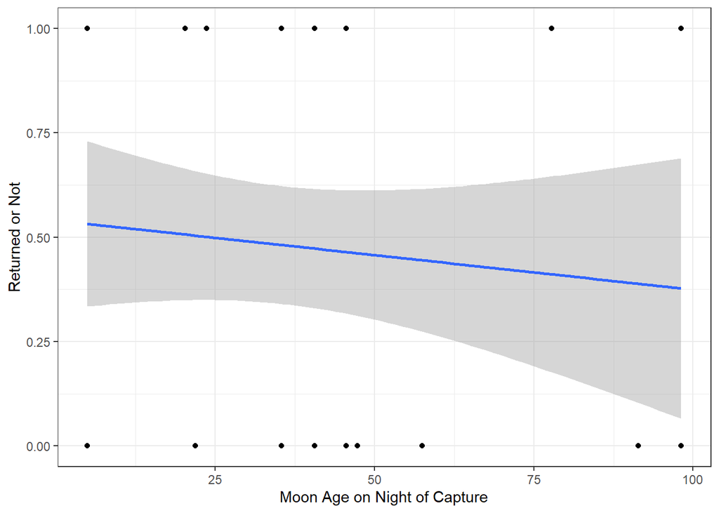

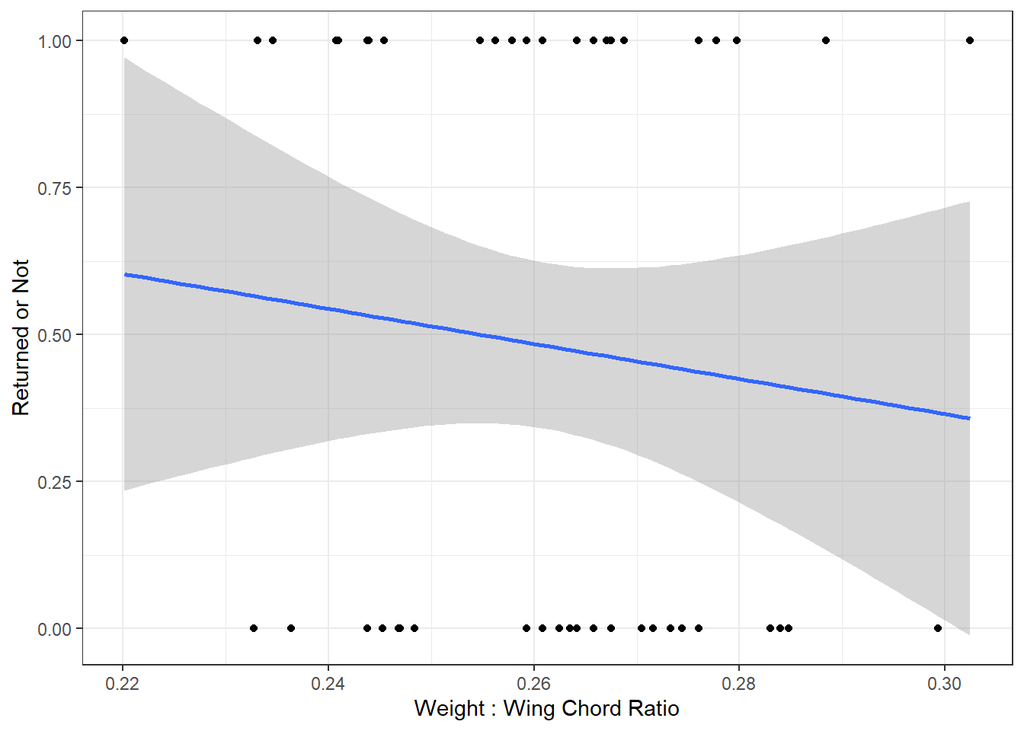

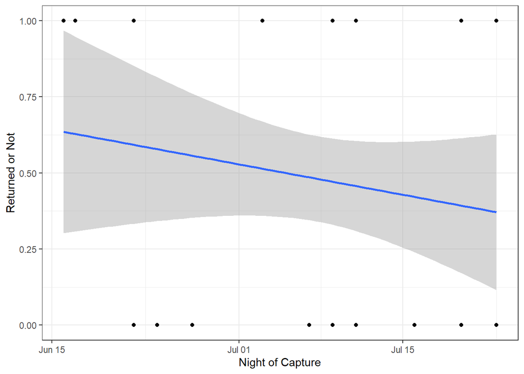

Night of capture is the only factor to pass a significance threshold of 0.05 in the GLM. For individuals that returned at least once, we can run a GLM with the same covariates to look at their effect on the number of visits (which ranges from 1 to 19). We could also include the birds that never returned at all with an n of 0, but I think we would want to use a zero-weighted or hurdle model in that case.

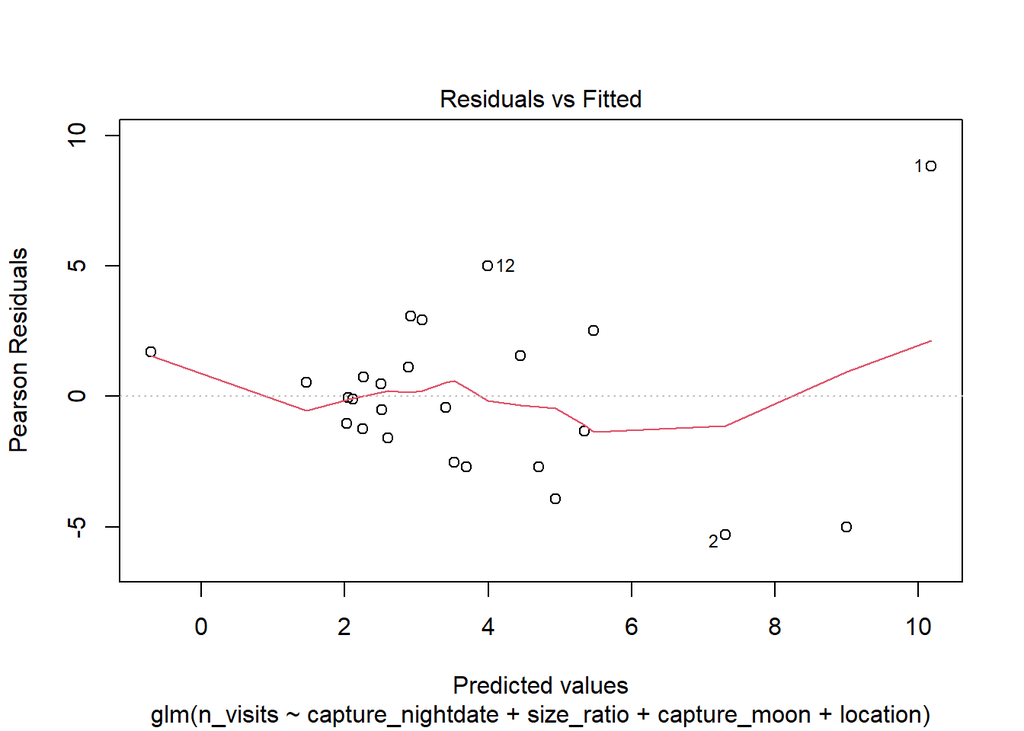

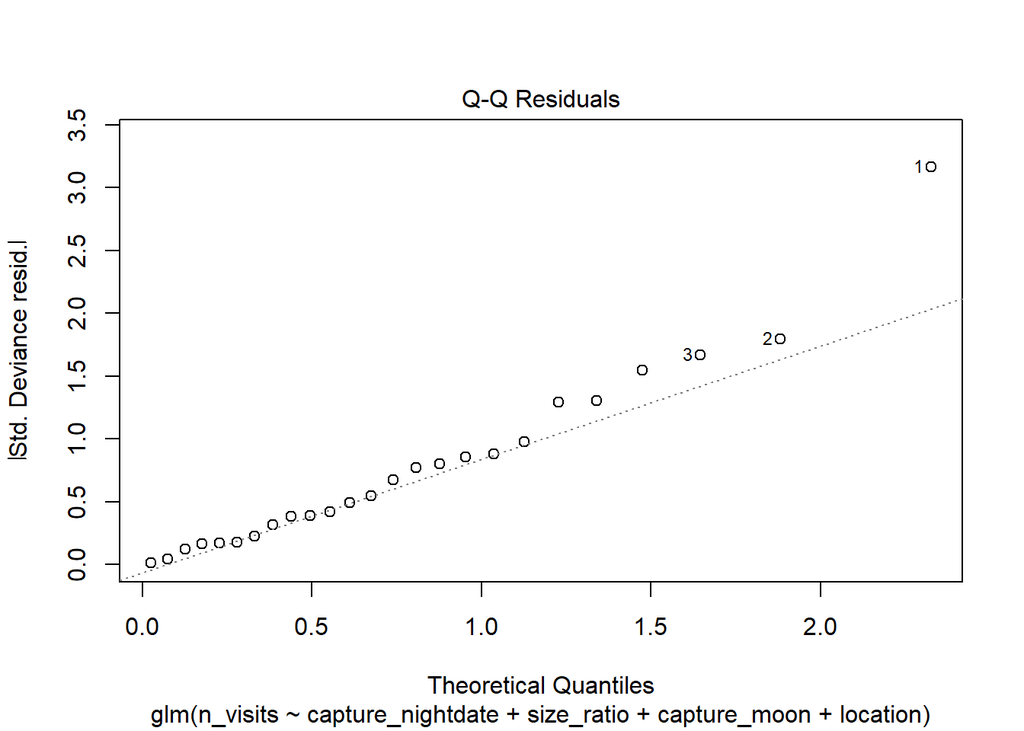

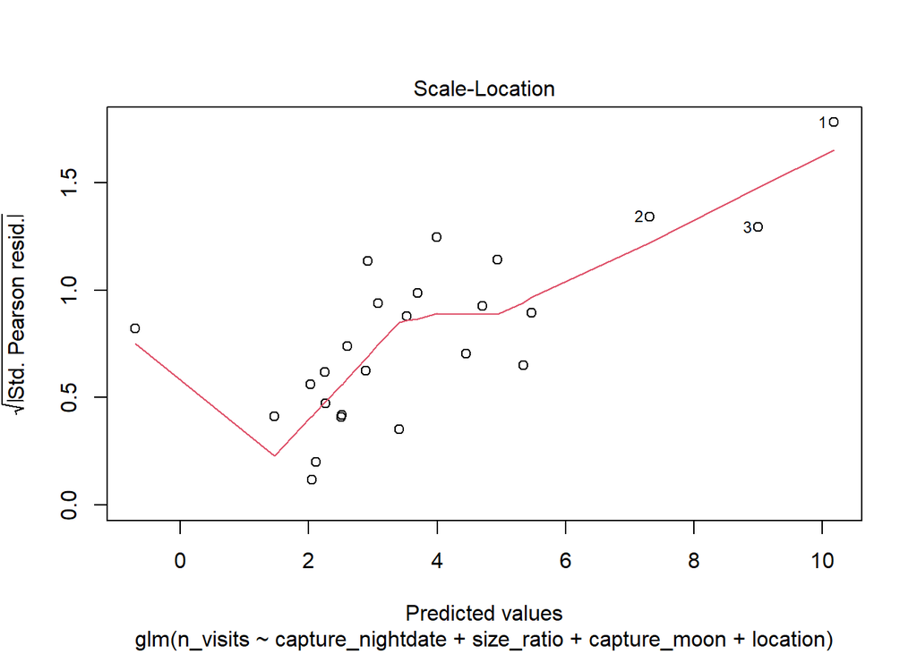

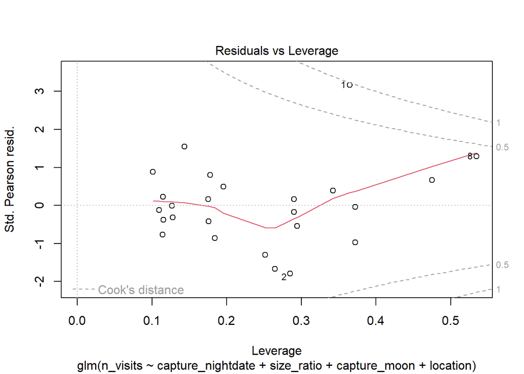

```r
n_visits <- prospecting_detections %>%
  filter(tag_id %in% visitors) %>%
  filter(nightdate != capture_nightdate) %>%
  group_by(tag_id) %>%
  summarize(n_visits = length(unique(nightdate)))

bd2 <- left_join(bd1, n_visits, by = "tag_id")

bd2 <- bd2 %>%
  filter(!is.na(n_visits))

glm2 <- glm(data = bd2, n_visits ~ capture_nightdate + size_ratio + capture_moon + location, family = gaussian(link = "identity"))

plot(glm2)
```

```r
anova(glm2)
```

```
Analysis of Deviance Table

Model: gaussian, link: identity

Response: n_visits

Terms added sequentially (first to last)

                  Df Deviance Resid. Df Resid. Dev      F  Pr(>F)
NULL                                 24     366.56
capture_nightdate  1   84.562        23     282.00 6.9197 0.01647 *
size_ratio         1   26.642        22     255.36 2.1801 0.15619
capture_moon       1    4.799        21     250.56 0.3927 0.53835
location           2   18.370        19     232.19 0.7516 0.48512
---
Signif. codes:  0 '***' 0.001 '**' 0.01 '*' 0.05 '.' 0.1 ' ' 1
```

In this case, night of capture is again significant.

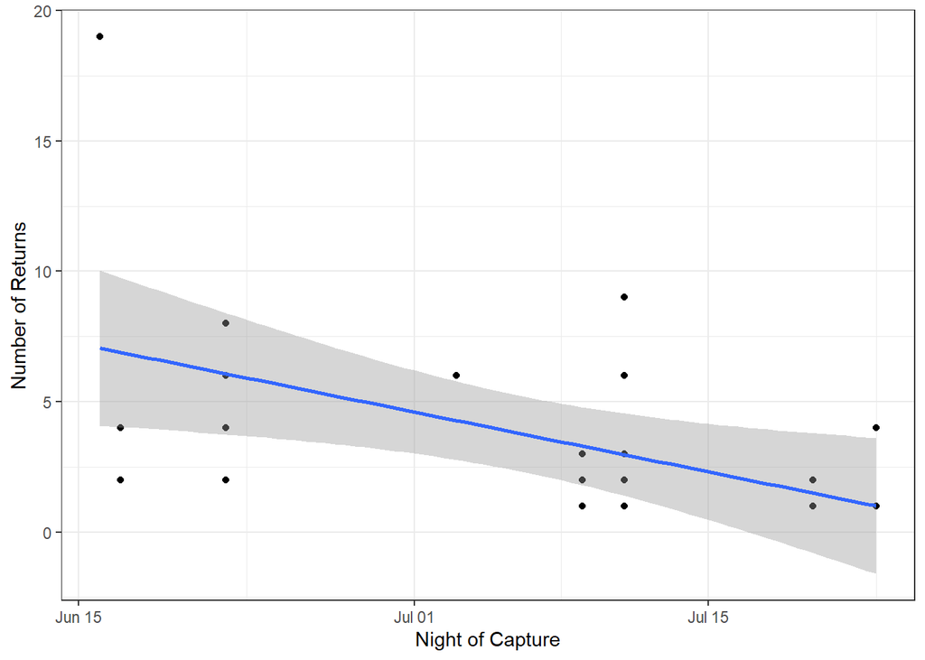

Some next steps might be to look at light and weather in regards to when pre-breeders attend colonies (are some nights detectably more appealing to them?) and the time they spend at colonies per night. I am also trying to think of some good ways to summarize and visualize the number and frequency of inter-colony movements.

## Arrival Times, Departure Times, and Visit Lengths

### Typical Arrival Time

[figure not shown]

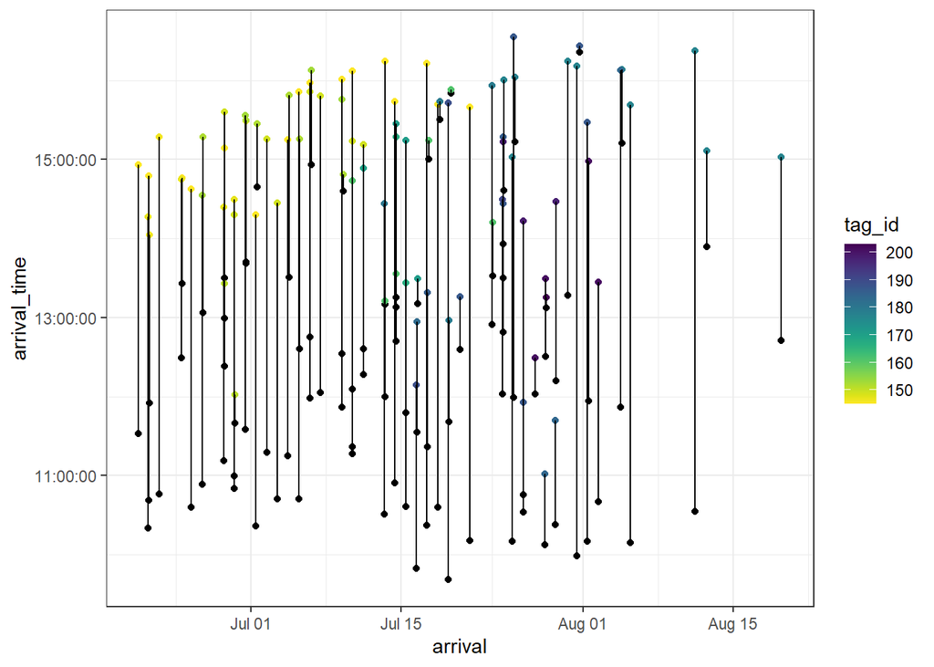

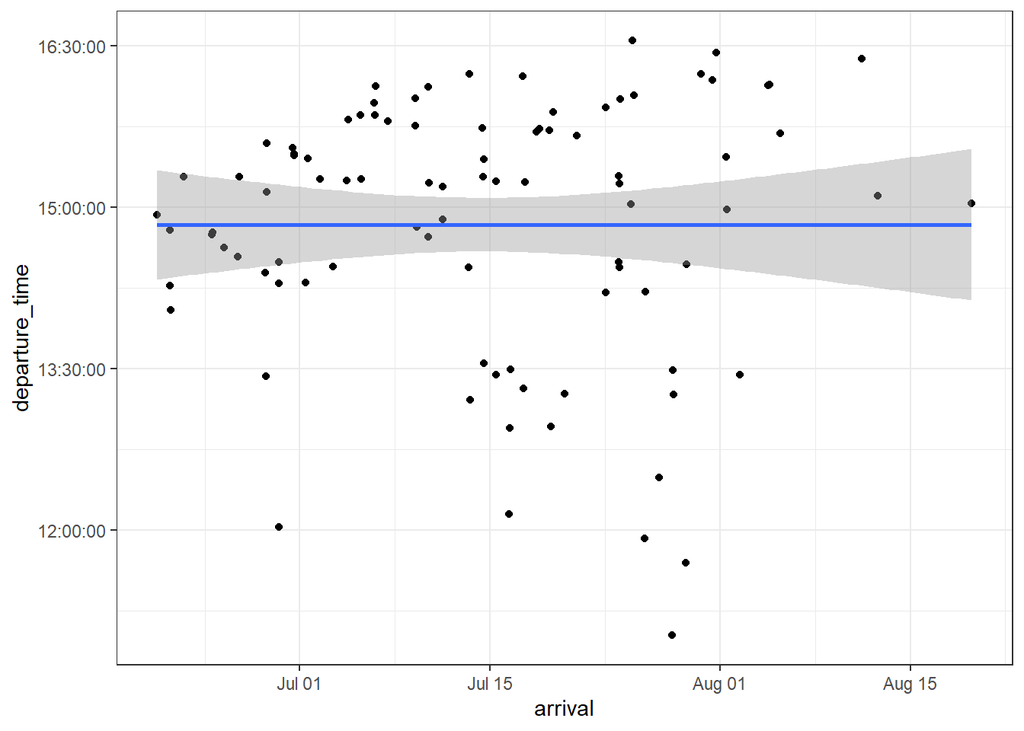

### SCRAPS

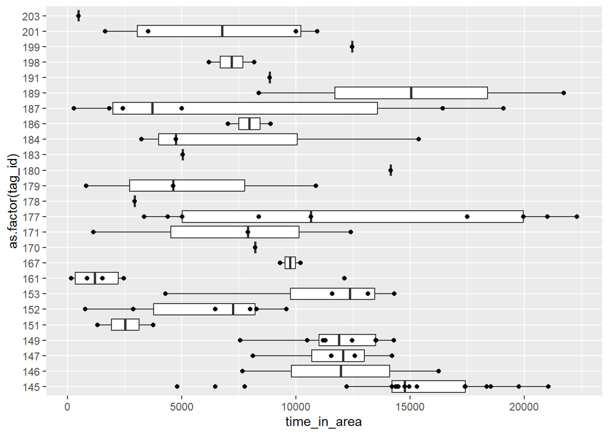

[output not shown]

[output cut: 299 more lines]

[output not shown]

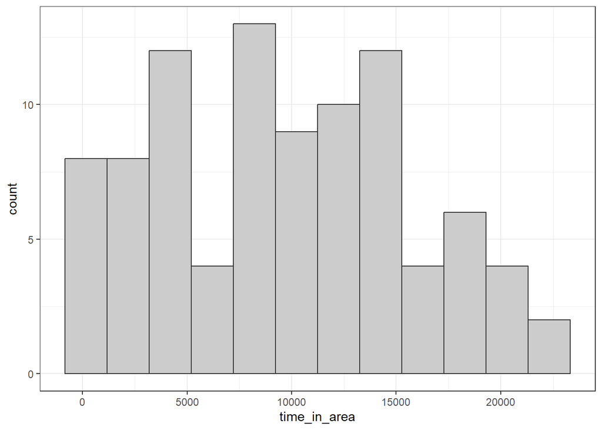

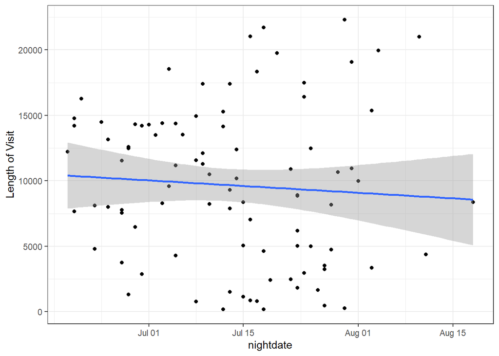

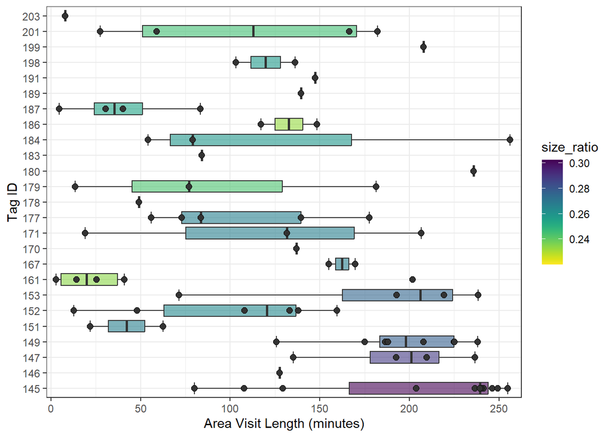

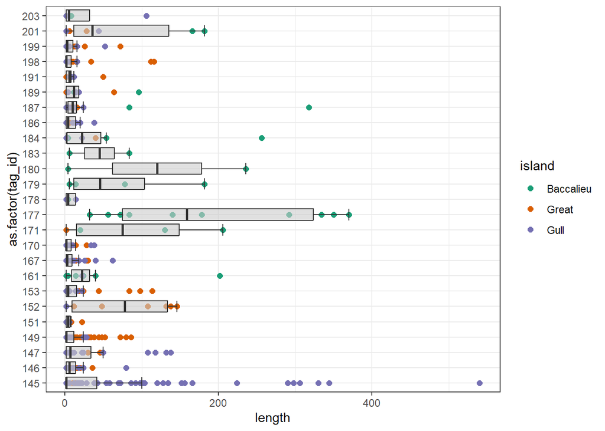

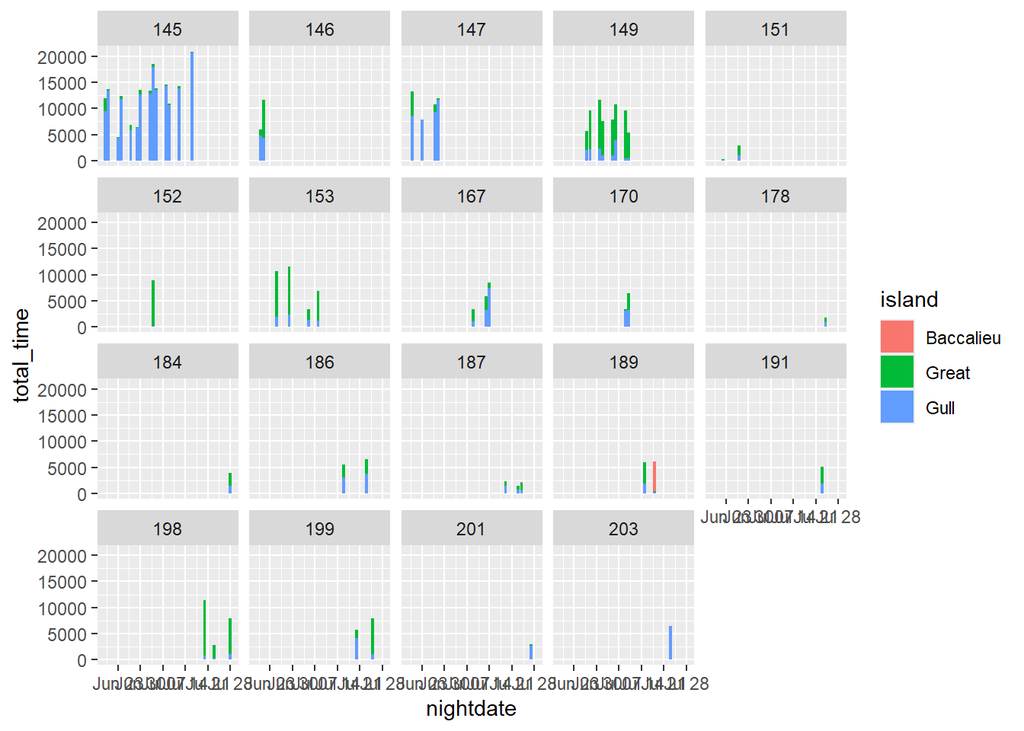

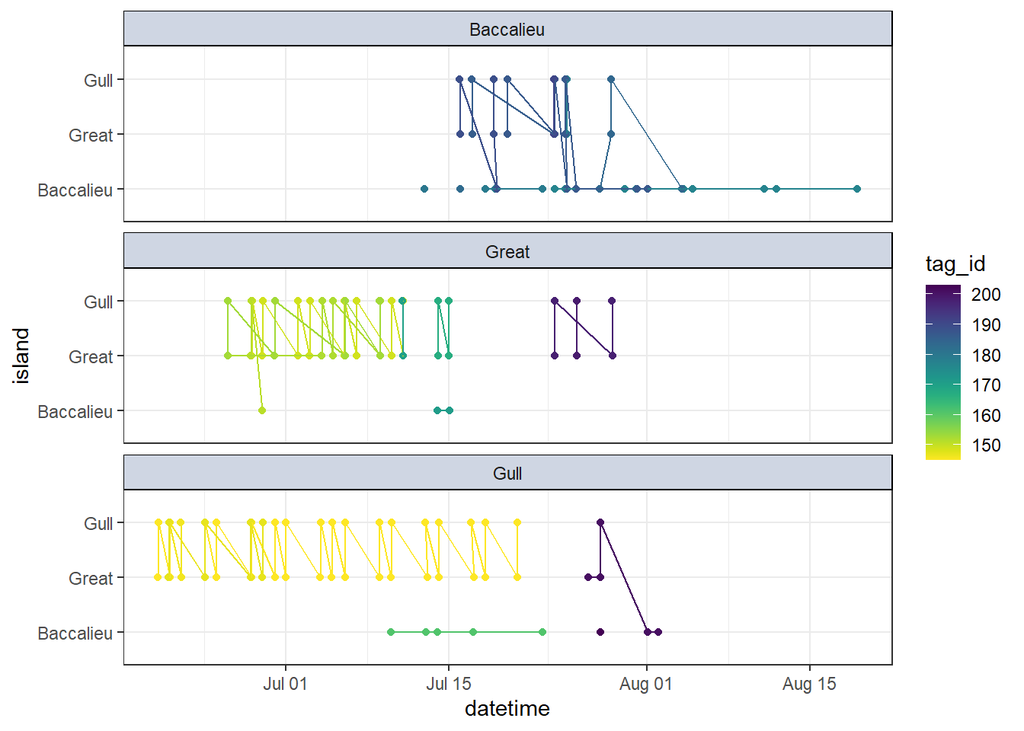

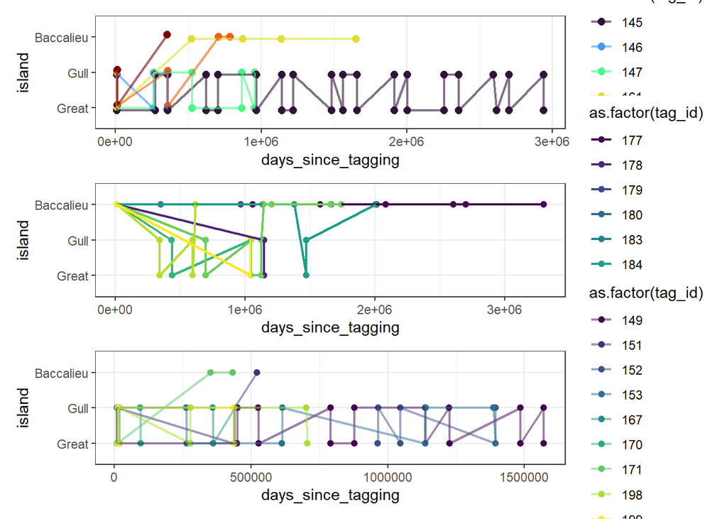